# Lab_1

```python
import pandas as pd
import numpy as np
import seaborn as sns
import matplotlib.pyplot as plt
from sklearn.linear_model import LinearRegression
from sklearn.metrics import mean_squared_error, mean_absolute_error
from sklearn.model_selection import train_test_split
```

### Goal:

To train the univariate linear regression models to predict median house values(dependent variable) based on independent variables(median income, population, and number of households)

```python
data_url = "https://raw.githubusercontent.com/ageron/handson-ml/master/datasets/housing/housing.csv"
df = pd.read_csv(data_url)
```

```python
#Exploratory data analysis
print("Dataset Statistics:")
print(df.describe())
```

```
Dataset Statistics:
          longitude      latitude  housing_median_age   total_rooms  \
count  20640.000000  20640.000000        20640.000000  20640.000000
mean    -119.569704     35.631861           28.639486   2635.763081
std        2.003532      2.135952           12.585558   2181.615252
min     -124.350000     32.540000            1.000000      2.000000
25%     -121.800000     33.930000           18.000000   1447.750000
50%     -118.490000     34.260000           29.000000   2127.000000
75%     -118.010000     37.710000           37.000000   3148.000000
max     -114.310000     41.950000           52.000000  39320.000000

       total_bedrooms    population    households  median_income  \
count    20433.000000  20640.000000  20640.000000   20640.000000
mean       537.870553   1425.476744    499.539680       3.870671
std        421.385070   1132.462122    382.329753       1.899822
min          1.000000      3.000000      1.000000       0.499900
25%        296.000000    787.000000    280.000000       2.563400
50%        435.000000   1166.000000    409.000000       3.534800
75%        647.000000   1725.000000    605.000000       4.743250
max       6445.000000  35682.000000   6082.000000      15.000100

       median_house_value
count        20640.000000
mean        206855.816909
std         115395.615874
min          14999.000000
25%         119600.000000
50%         179700.000000
75%         264725.000000
max         500001.000000
```

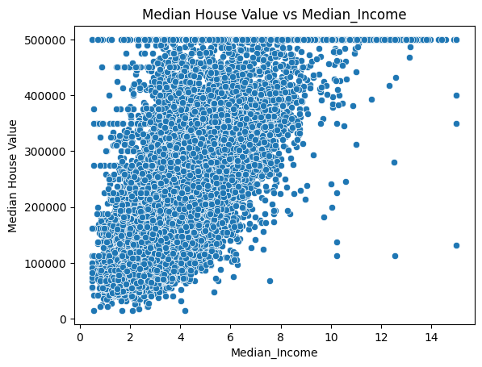

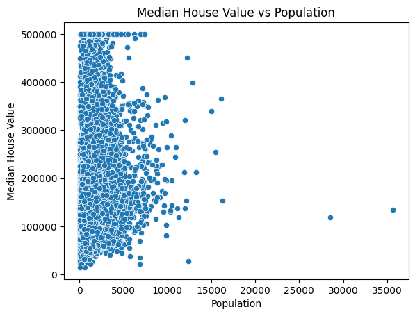

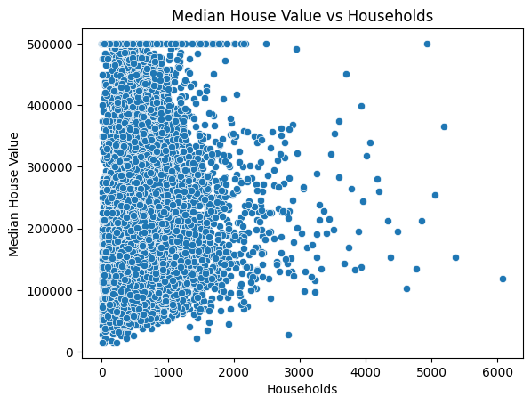

```python
# Scatter plots for median house value vs Independent variables
variables = ['median_income', 'population', 'households']
for var in variables:
    sns.scatterplot(data=df, x=var, y='median_house_value').set_title(f'Median House Value vs {var.title()}')
    plt.xlabel(var.title())
    plt.ylabel('Median House Value')
    plt.show()
```

**Median House Value:** Median house price for a given district in California and is the dependent variable. Range 15000-500000. Observation of the plot concludes, there are more less priced houses, but few districts have high values.

**Median Income:** Median income of households in the district. Range 0-15+. The plot shows high income leading to higher house values. Correlation with house prices which is positive.

```python
# Initialize a dictionary to store results
results = {
    "Variable": [],
    "Intercept": [],
    "Slope": [],
    "MSE": [],
    "MAE": []
}
```

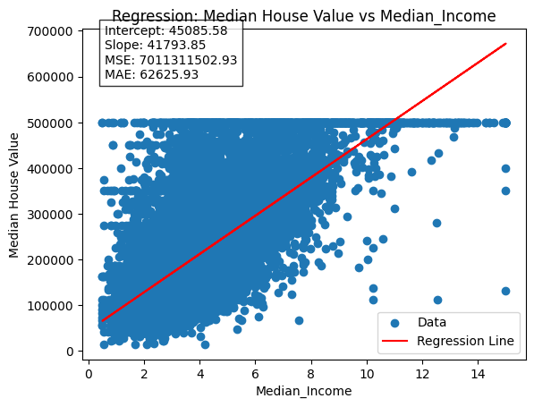

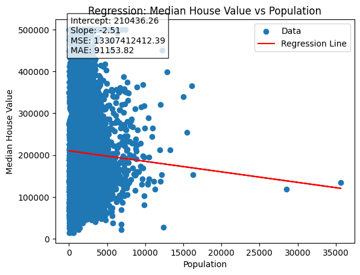

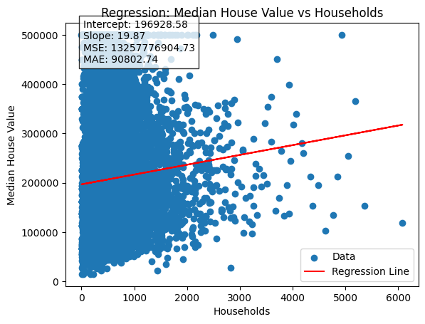

```python
# linear regression models for each variable
for var in variables:

    X = df[[var]].values
    y = df['median_house_value'].values

    # Splitting data set into training and testing
    X_train, X_test, y_train, y_test = train_test_split(X, y, test_size=0.2, random_state=42)

    model = LinearRegression()
    model.fit(X, y)

    # Predictions
    y_pred = model.predict(X)

    # Calculate metrics
    intercept = model.intercept_
    slope = model.coef_[0]
    mse = mean_squared_error(y, y_pred)
    mae = mean_absolute_error(y, y_pred)

    # Store results
    results["Variable"].append(var.title())
    results["Intercept"].append(intercept)
    results["Slope"].append(slope)
    results["MSE"].append(mse)
    results["MAE"].append(mae)

    # 6. Plotting the regression line
    plt.scatter(X, y, label="Data")
    plt.plot(X, y_pred, color="red", label="Regression Line")
    plt.title(f"Regression: Median House Value vs {var.title()}")
    plt.xlabel(var.title())
    plt.ylabel("Median House Value")
    plt.legend()

    # metrics in box
    plt.text(
        0.05, 0.85,
        f"Intercept: {intercept:.2f}\nSlope: {slope:.2f}\nMSE: {mse:.2f}\nMAE: {mae:.2f}",
        transform=plt.gca().transAxes,
        fontsize=10,
        bbox=dict(facecolor="white", alpha=0.8)
    )
    plt.show()
```

```python
results_df = pd.DataFrame(results)
print("Regression Metrics Table:")
print(results_df)
```

```
Regression Metrics Table:
        Variable      Intercept         Slope           MSE           MAE
0  Median_Income   45085.576703  41793.849202  7.011312e+09  62625.933791
1     Population  210436.262076     -2.511753  1.330741e+10  91153.820095
2     Households  196928.577162     19.872775  1.325778e+10  90802.743243
```

## Summary:

From the analysis, we trained univariate linear regression models using the three independent variables to predict median house value.

- **Median income model:** the best predictor of house value, the slope is steep, indicating a positive relationship. Lowest MSE and MAE.
- **Population model:** Weak correlation with house prices. Flat slope showing less effect on price. High MSE and MAE.
- **Household model:** Similar behaviour to population. Flat slope indicating a weak predictor. High MSE and MAE.

### Key Findings:

- Since homes in higher-income locations tend to be more costly, income is the most significant factor in influencing house prices.
- Households and population have little impact on home values, indicating that demand, location, and employment opportunities are more important considerations.